# Matplotlib Object Oriented Method

## Figure size and DPI

Matplotlib allows the aspect ratio, DPI and figure size to be specified when the Figure object is created. You can use the `figsize` and `dpi` keyword arguments.

- `figsize` is a tuple of the width and height of the figure in inches
- `dpi` is the dots-per-inch (pixel per inch).

For example:

```
fig = plt.figure(figsize=(8,4), dpi=100)
```

The same arguments can also be passed to layout managers, such as the `subplots` function:

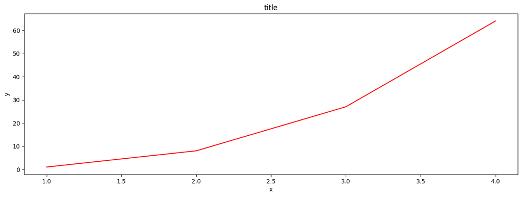

```python
fig, axes = plt.subplots(figsize=(15,5),dpi = 100) #figsize(width,ht)

axes.plot(x, y, 'r')
axes.set_xlabel('x')
axes.set_ylabel('y')
axes.set_title('title')
```

## Title, Labels and Legends

Now that we have covered the basics of how to create a figure canvas and add axes instances to the canvas, let's look at how decorate a figure with titles, axis labels, and legends.

**Figure titles**

A title can be added to each axis instance in a figure. To set the title, use the `set_title` method in the axes instance:

```
ax.set_title("title")
```

**Axis labels**

Similarly, with the methods `set_xlabel` and `set_ylabel`, we can set the labels of the X and Y axes:

```
ax.set_xlabel("x")
ax.set_ylabel("y")
```

### Legends

You can use the **label="label text"** keyword argument when plots or other objects are added to the figure, and then using the **legend** method without arguments to add the legend to the figure:

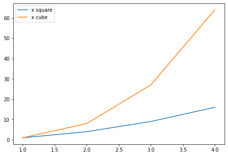

```python
fig = plt.figure()

ax = fig.add_axes([0,0,1,1])

ax.plot(x, x**2, label="x square")
ax.plot(x, x**3, label="x cube")
ax.legend();
```

Notice how are legend overlaps some of the actual plot!

The **legend** function takes an optional keyword argument **loc** that can be used to specify where in the figure the legend is to be drawn. The allowed values of **loc** are numerical codes for the various places the legend can be drawn. See the [documentation page](http://matplotlib.org/users/legend_guide.html#legend-location) for details. Some of the most common **loc** values are:

- upper right corner : `ax.legend(loc=1)`
- upper left corner:`ax.legend(loc=2` # upper left corner
- lower left corner:`ax.legend(loc=3)` # lower left corner
- lower right corner:`ax.legend(loc=4)` # lower right corner

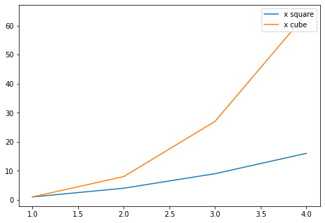

```python
fig = plt.figure()

ax = fig.add_axes([0,0,1,1])

ax.plot(x, x**2, label="x square")
ax.plot(x, x**3, label="x cube")
ax.legend(loc=1);
```

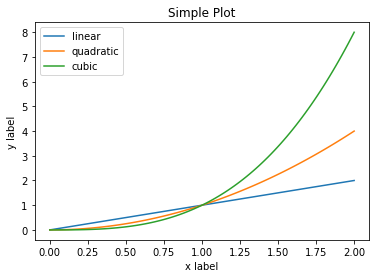

```python
x = np.linspace(0, 2, 100)

fig, ax = plt.subplots()  # Create a figure and an axes.

ax.plot(x, x, label='linear')  # Plot some data on the axes.
ax.plot(x, x**2, label='quadratic')  # Plot more data on the axes...
ax.plot(x, x**3, label='cubic')  # ... and some more.

ax.set_xlabel('x label')  # Add an x-label to the axes.
ax.set_ylabel('y label')  # Add a y-label to the axes.
ax.set_title("Simple Plot")  # Add a title to the axes.
ax.legend()  # Add a legend.

plt.show()
```

### Multiple plots in one figure

```python
# importing the matplotlib library
import matplotlib.pyplot as plt

# defining the values of X
x =[0, 1, 2, 3, 4, 5, 6]

# defining the value of Y
y =[0, 1, 3, 6, 9, 12, 17]
```

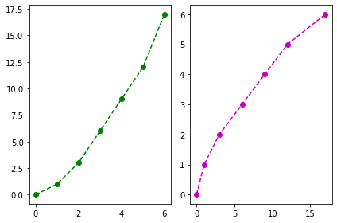

```python
# creating the canvas with class 'fig' and it's object 'axes' with '1' row and '2' columns
fig, axes = plt.subplots(1, 2)

# plotting graph for 1st column
axes[0].plot(x, y, 'g--o')

# plotting graph for second column
axes[1].plot(y, x, 'm--o')

# Gives a clean look to the graphs
fig.tight_layout()
```

#### Another complex example:

```python
# importing the matplotlib library
import matplotlib.pyplot as plt

# defining the values of X
x =[0, 1, 2, 3, 4, 5, 6]

# defining the value of Y
y =[0, 1, 3, 6, 9, 12, 17]
```

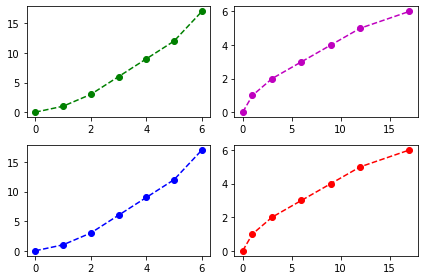

```python
# creating the canvas with class 'fig' and it's object 'axes' with '2' row and '2' columns
fig, axes = plt.subplots(2, 2)

# plotting graph for 1st element
axes[0, 0].plot(x, y, 'g--o')

# plotting graph for 2nd element
axes[0, 1].plot(y, x, 'm--o')

# plotting graph for 3rd element
axes[1, 0].plot(x, y, 'b--o')

# plotting graph for 4th element
axes[1, 1].plot(y, x, 'r--o')

# Gives a clean look to the graphs
fig.tight_layout()
```

## Setting colors, linewidths, linetypes

Matplotlib gives you *a lot* of options for customizing colors, linewidths, and linetypes.

#### Colors with MatLab like syntax

With matplotlib, we can define the colors of lines and other graphical elements in a number of ways. First of all, we can use the MATLAB-like syntax where `'b'` means blue, `'g'` means green, etc. The MATLAB API for selecting line styles are also supported: where, for example, `'b.-'` means a blue line with dots:

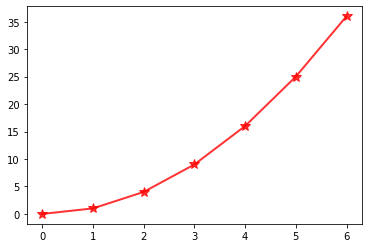

```python
# MATLAB style line color and style
x = np.array([0, 1, 2, 3, 4, 5, 6])

fig, ax = plt.subplots()

ax.plot(x, x**2, color = 'red', linewidth = 2,
        alpha = 0.8,marker ='*',markersize = 10); #alpha defines transparency

# ax.plot(x, x**2, 'b.-'); # blue line with dots

# ax.plot(x, x**3, 'g--'); # green dashed line

# ax.plot(x,x**2, 'y.-');

# ax.plot(x,x**3, 'g--');
```

### Colors with the `color =` parameter

We can also define colors by their names or RGB hex codes and optionally provide an alpha value using the `color` and `alpha` keyword arguments. Alpha indicates opacity.

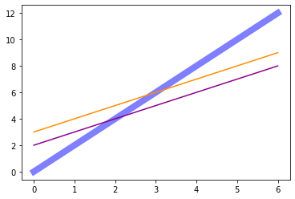

```python
x = np.array([0, 1, 2, 3, 4, 5, 6])

fig, ax = plt.subplots()

ax.plot(x, x*2, color="blue", linewidth = 8, alpha=0.5) # half-transparant
ax.plot(x, x+2, color="#8B008B")        # RGB hex code
ax.plot(x, x+3, color="#FF8C00");        # RGB hex code
```

## Control over axis appearance

In this section we will look at controlling axis sizing properties in a matplotlib figure.

#### Plot range

We can configure the ranges of the axes using the `set_ylim` and `set_xlim` methods in the axis object, or `axis('tight')` for automatically getting "tightly fitted" axes ranges:

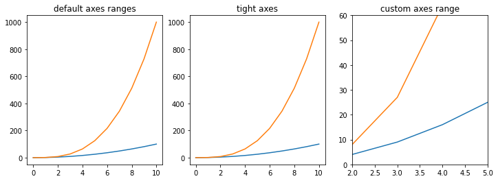

```python
x = np.array([0, 1, 2, 3, 4, 5, 6, 7, 8, 9, 10])

fig, axes = plt.subplots(1,3,figsize=(12, 4))

axes[0].plot(x, x**2, x, x**3)
axes[0].set_title("default axes ranges")

axes[1].plot(x, x**2, x, x**3)
axes[1].axis('tight')
axes[1].set_title("tight axes")

axes[2].plot(x, x**2, x, x**3)
axes[2].set_ylim([0, 60])
axes[2].set_xlim([2, 5])#([lower bound,upper bound])
axes[2].set_title("custom axes range");
```

### Some more miscellaneous relevant Example:

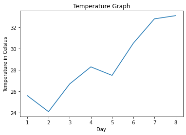

```python
import matplotlib.pyplot as plt

days = list(range(1,9))
celsius_values = [25.6, 24.1, 26.7, 28.3, 27.5, 30.5, 32.8, 33.1]

fig, ax = plt.subplots()

ax.plot(days, celsius_values)

ax.set(xlabel='Day',
       ylabel='Temperature in Celsius',
       title='Temperature Graph')

plt.show()
```

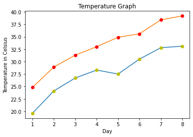

```python
import matplotlib.pyplot as plt

days = list(range(1,9))
celsius_min = [19.6, 24.1, 26.7, 28.3, 27.5, 30.5, 32.8, 33.1]
celsius_max = [24.8, 28.9, 31.3, 33.0, 34.9, 35.6, 38.4, 39.2]

fig, ax = plt.subplots()

ax.set(xlabel='Day',
       ylabel='Temperature in Celsius',
       title='Temperature Graph')


ax.plot(days, celsius_min,
        days, celsius_min, "oy",
        days, celsius_max,
        days, celsius_max, "or")

plt.show()
```

We could have used for plot calls in the previous code instead of one:

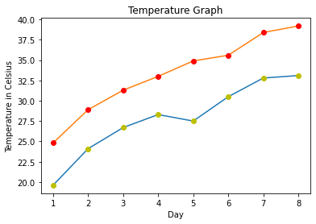

```python
import matplotlib.pyplot as plt

days = list(range(1, 9))
celsius_min = [19.6, 24.1, 26.7, 28.3, 27.5, 30.5, 32.8, 33.1]
celsius_max = [24.8, 28.9, 31.3, 33.0, 34.9, 35.6, 38.4, 39.2]

fig, ax = plt.subplots()

ax.set(xlabel='Day',
       ylabel='Temperature in Celsius',
       title='Temperature Graph')

ax.plot(days, celsius_min)
ax.plot(days, celsius_min, "oy")
ax.plot(days, celsius_max)
ax.plot(days, celsius_max, "or")

plt.show()
```

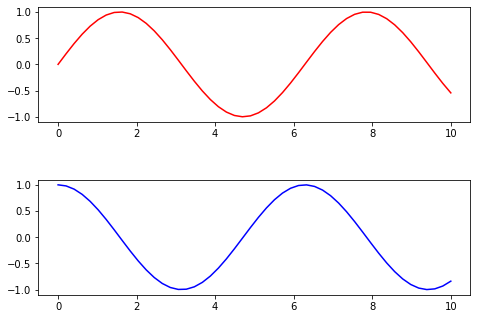

```python
x = np.linspace(start = 0, stop = 10, num = 50)

fig = plt.figure()

ax1 = fig.add_axes([0, 0.6, 1, 0.4])
ax2 = fig.add_axes([0, 0, 1, 0.4])

ax1.plot(x, np.sin(x),'r')
ax2.plot(x, np.cos(x),'b')

plt.show()
```

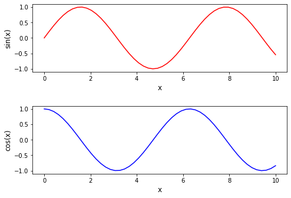

```python
fig = plt.figure()

ax1 = fig.add_axes([0, 0.6, 1, 0.4])
ax2 = fig.add_axes([0, 0, 1, 0.4])

ax1.plot(x, np.sin(x),'r')
ax1.set_xlabel('x', fontsize=12)
ax1.set_ylabel('sin(x)', fontsize=12)

ax2.plot(x, np.cos(x),'b')
ax2.set_xlabel('x', fontsize=12)
ax2.set_ylabel('cos(x)', fontsize=12)

plt.show()
```

### Multiple plots in one figure

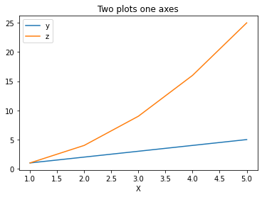

```python
import matplotlib.pyplot as plt

# Function to get the square of each element in the list
def list_square(a_list):
    return [element**2 for element in a_list]

# Multiple plot in same subplot window i.e., to plot y = x and z = x^2 in the same subplot window
fig2 = plt.figure()

x = [1, 2, 3, 4, 5]
y = x
z = list_square(x)

# Get the axes instance
ax = fig2.add_subplot(1,1,1)

# Plot y vs x as well as z vs x. label will be used by ax.legend() method to generate a legend automatically
ax.plot(x, y, label='y')
ax.plot(x, z, label='z')
ax.set_xlabel("X")

# Generate legend
ax.legend()

# Set title
ax.set_title('Two plots one axes')

# Display
plt.show()
```

### Multiple sub-plots in one figure

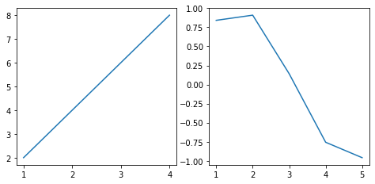

```python
fig = plt.figure(figsize=(8,8))

ax1 = fig.add_subplot(221) # create 2*2 figure and 1 represent no of the figure
ax1.plot([1, 2, 3, 4],
        [2, 4, 6, 8])

ax2 = fig.add_subplot(222) # create 2*2 figure and 2 represent no of the figure
ax2.plot(x, np.sin(x))

plt.show()
```

#### Another complex example

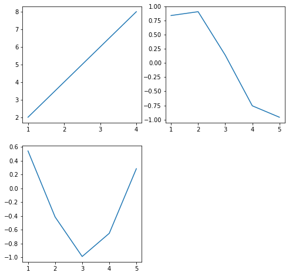

```python
fig = plt.figure(figsize=(8,8))

ax1 = fig.add_subplot(221) # create 2*2 figure and 1 represent no of the figure
ax1.plot([1, 2, 3, 4],
        [2, 4, 6, 8])

ax2 = fig.add_subplot(222) # create 2*2 figure and 2 represent no of the figure
ax2.plot(x, np.sin(x))

ax3 = fig.add_subplot(223) # create 2*2 figure and 3 represent no of the figure
ax3.plot(x, np.cos(x))

plt.show()
```

Read this blog to know more about difference between `.plt()` and object-oriented plotting:

https://matplotlib.org/matplotblog/posts/pyplot-vs-object-oriented-interface/

# Special Plot Types

There are many specialized plots we can create, such as barplots, histograms, scatter plots, and much more. Most of these type of plots we will actually create using seaborn, a statistical plotting library for Python. But here are a few examples of these type of plots:

## Bar Plot

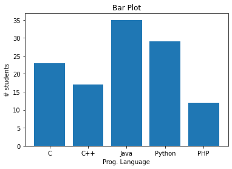

```python
#data
langs = ['C', 'C++', 'Java', 'Python', 'PHP']
students = [23,17,35,29,12]

#plotting bar plot
fig, ax = plt.subplots()

ax.bar(langs,students)
ax.set_title("Bar Plot")
ax.set_xlabel("Prog. Language")
ax.set_ylabel("# students")
plt.show()
```

```python
#try to plot a horizontal bar plot here
```

#### Grouped Bar Plot

The data object is a multidict containing number of students passed in three branches of an engineering college over the last four years. We can plot multiple bar charts by playing with the thickness and the positions of the bars.

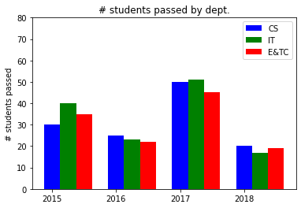

```python
data = [[30, 25, 50, 20],
[40, 23, 51, 17],
[35, 22, 45, 19]]

X = np.arange(4)

#plotting grouped bar chart
fig, ax = plt.subplots()

ax.bar(X + 0.00, data[0], color = 'b', width = 0.25)
ax.bar(X + 0.25, data[1], color = 'g', width = 0.25)
ax.bar(X + 0.50, data[2], color = 'r', width = 0.25)

#adding details
ax.set_ylabel('# students passed')
ax.set_title('# students passed by dept.')
ax.set_xticks(X, ('2015', '2016', '2017', '2018'))
ax.set_yticks(np.arange(0, 81, 10))
ax.legend(labels=['CS', 'IT', 'E&TC'])

plt.show()
```

#### Stacked Bar Plot

The stacked bar chart stacks bars that represent different groups on top of each other. The height of the resulting bar shows the combined result of the groups: 'G1', 'G2', 'G3', 'G4', 'G5'.

`bottom =` allows you to specify a starting value for a bar instead of zero

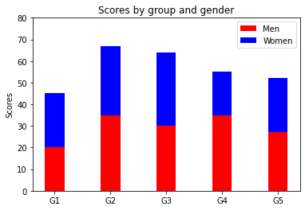

```python
import numpy as np
import matplotlib.pyplot as plt

N = 5
menMeans = (20, 35, 30, 35, 27)
womenMeans = (25, 32, 34, 20, 25)
ind = np.arange(N) # the x locations for the groups

width = 0.35

#plotting
fig, ax = plt.subplots()

ax.bar(ind, menMeans, width, color='r')
ax.bar(ind, womenMeans, width,bottom=menMeans, color='b')
ax.set_ylabel('Scores')
ax.set_title('Scores by group and gender')
ax.set_xticks(ind,('G1', 'G2', 'G3', 'G4', 'G5'))
ax.set_yticks(np.arange(0, 81, 10))
ax.legend(labels=['Men', 'Women'])
plt.show()
```

## Histogram

Following example plots a histogram of marks obtained by students in a class. Four bins, 0-25, 26-50, 51-75, and 76-100 are defined. The Histogram shows number of students falling in this range.

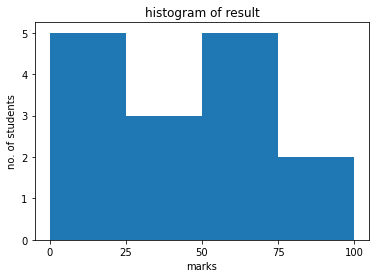

```python
a = np.array([22,87,5,43,56,73,55,54,11,20,51,5,79,31,27])

fig, ax = plt.subplots()

plt.hist(a, bins = [0,25,50,75,100])

ax.set_title("histogram of result")
ax.set_xticks([0,25,50,75,100])
ax.set_xlabel('marks')
ax.set_ylabel('no. of students')
plt.show()
```

## Pie Chart

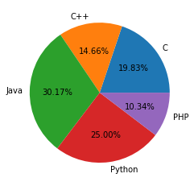

```python
langs = ['C', 'C++', 'Java', 'Python', 'PHP']
students = [23,17,35,29,12]

fig, ax = plt.subplots()

ax.pie(students, labels = langs,autopct='%1.2f%%') # autopct defines the percentage in sections
plt.show()
```

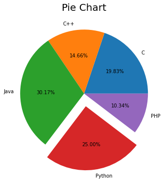

```python
langs = ['C', 'C++', 'Java', 'Python', 'PHP']
students = [23,17,35,29,12]

fig, ax = plt.subplots(figsize = (6,6))

explode = [0,0,0,0.2,0]  # for displaying python as a slice of pie

ax.pie(students, explode=explode, labels = langs,autopct='%1.2f%%') # autopct defines the percentage in sections
ax.set_title("Pie Chart",fontsize = 20)
plt.show()
```

## Saving figures

Matplotlib can generate high-quality output in a number formats, including PNG, JPG, EPS, SVG, PGF and PDF.

To save a figure to a file we can use the `savefig` method in the `Figure` class:

```python
# fig.savefig("filename.png")

fig.savefig("filename1.png")
```

Here we can also optionally specify the DPI and choose between different output formats:

```python
fig.savefig("filename.png", dpi=200)
```